# Feature Engineering

Ali Zaidi

2017/06/06

## Exploratory Data Analysis and Feature Engineering

Import your favorite libraries and set up your favorite plotting theme.

```r
library(readr)    # for reading data
library(dplyr)    # for data manipluation
library(tidyr)    # for data aggregation and spreading
library(purrr)    # for functionals and closures
library(ggplot2)  # for visualizations
library(maps)     # for maps data
library(scales)   # for units
theme_set(theme_minimal())      # setting up your default theme
```

Now let’s import some data. Our [data source](http://www.dcc.fc.up.pt/~ltorgo/Regression/cal_housing.html) is 1990-census level of housing in California.

We’ll use easy the `readr` package to load in our data. You could equivalently use `read.csv`, or `data.table::fread` if you wanted incredible speed. We’ll later see how to use data sources using the `RevoScaleR` readers.

Since we’re using `readr`, our data is a `tbl`. This means we will get some `dplyr` and `tibble` features, and it’ll behave a little differently than a traditional `data.frame`.

| longitude | latitude | housing_median_age | total_rooms | total_bedrooms | population | households | median_income | median_house_value | ocean_proximity |
| --- | --- | --- | --- | --- | --- | --- | --- | --- | --- |
| -122.23 | 37.88 | 41 | 880 | 129 | 322 | 126 | 8.3252 | 452600 | NEAR BAY |
| -122.22 | 37.86 | 21 | 7099 | 1106 | 2401 | 1138 | 8.3014 | 358500 | NEAR BAY |
| -122.24 | 37.85 | 52 | 1467 | 190 | 496 | 177 | 7.2574 | 352100 | NEAR BAY |
| -122.25 | 37.85 | 52 | 1274 | 235 | 558 | 219 | 5.6431 | 341300 | NEAR BAY |
| -122.25 | 37.85 | 52 | 1627 | 280 | 565 | 259 | 3.8462 | 342200 | NEAR BAY |
| -122.25 | 37.85 | 52 | 919 | 213 | 413 | 193 | 4.0368 | 269700 | NEAR BAY |
| -122.25 | 37.84 | 52 | 2535 | 489 | 1094 | 514 | 3.6591 | 299200 | NEAR BAY |
| -122.25 | 37.84 | 52 | 3104 | 687 | 1157 | 647 | 3.1200 | 241400 | NEAR BAY |
| -122.26 | 37.84 | 42 | 2555 | 665 | 1206 | 595 | 2.0804 | 226700 | NEAR BAY |
| -122.25 | 37.84 | 52 | 3549 | 707 | 1551 | 714 | 3.6912 | 261100 | NEAR BAY |

[output cut: 990 more lines]

## Visualize Densities

Suppose we want to visualize the distribution of the numeric columns, such as **housing_median_age**. How would you visualize that density?

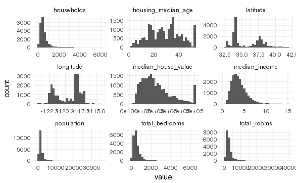

```r
housing %>% keep(is_double) %>%
  # select(-longitude, -latitude) %>%
  gather %>%
  ggplot(aes(x = value)) + geom_histogram() + facet_wrap(~key, scales = "free")
```

## Spatial Visualizations

The histograms of the longitude and latitude columns seem like they are in some reasonable range of data. Let’s visualize the locations.

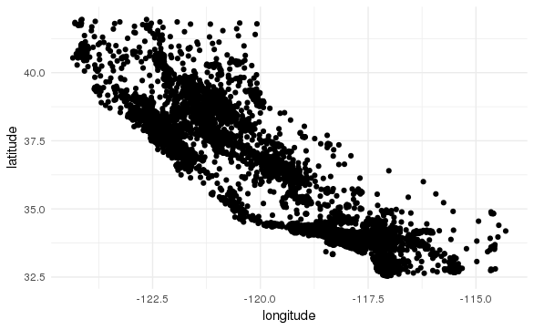

Looks indeed like California!

We can improve this chart in many ways. Let’s first add some transparency so we can get a better sense of the *density* of points:

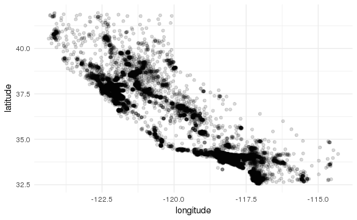

```r
housing %>% ggplot(aes(x = longitude, y = latitude)) +
  geom_point(alpha = 0.15)
```

Nice, we can already see some dense clusters for higher population regions like the Bay Area, Sacramento and Los Angeles.

Let’s add some additional attributes, like the population:

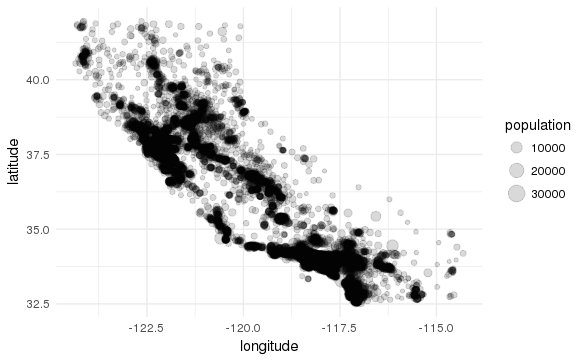

```r
housing %>% ggplot(aes(x = longitude, y = latitude,
                       size = population)) +
  geom_point(alpha = 0.15)
```

And now let’s see if we can add a gradient fill for another numeric value, like the median housing price:

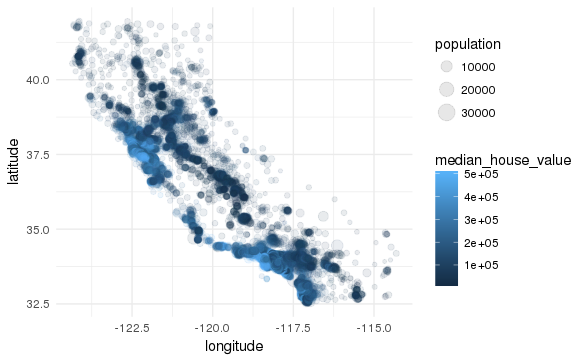

```r
housing %>% ggplot(aes(x = longitude, y = latitude,
                       size = population,
                       colour = median_house_value)) +
  geom_point(alpha = 0.095)
```

```r
  # scale_fill_gradient(low = "yellow", high = "red")
```

Interesting, we can definitely see the higher price ranges in LA and the Bay Area. Let’s see if we can change the colour scheme to get an even better visualization:

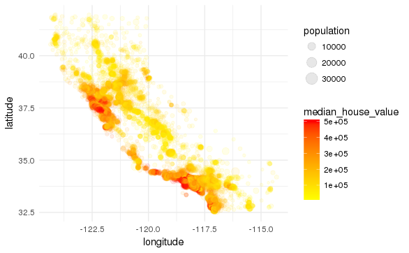

```r
housing %>% ggplot(aes(x = longitude, y = latitude,
                       size = population,
                       colour = median_house_value)) +
  geom_point(alpha = 0.095) +
  scale_colour_gradient(low = "yellow", high = "red")
```

If you want to plot the points on top of an actual polygon of the state map, you can do that using `geom_map` and using the `map_data` function in ggplot2. I find it a bit messy, but it might be worthwile if you are plotting various regions/states.

While we’re at it, let’s put some final themes on our plot to make it more aesthetically pleasing.

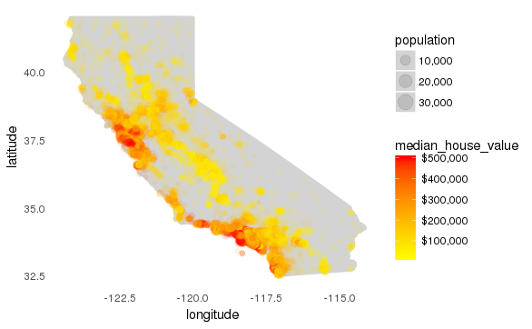

```r
housing %>%
  mutate(state = "california") %>%
  ggplot(aes(x = longitude, y = latitude,
             size = population,
             colour = median_house_value)) +
  geom_map(map = filter(map_data("state"), region == "california"),
           aes(map_id = state),
           fill = "lightgrey",
           colour = "lightgrey") +
  geom_point(alpha = 0.1) +
  theme(panel.grid.major = element_blank(),
        panel.grid.minor = element_blank()) +
  scale_size_continuous(labels = scales::comma) +
  scale_colour_gradient(low = "yellow", high = "red",
                        labels = scales::dollar)
```